# 4 結果と考察

## 4.1 分析対象と4状態の構成

本研究では、まずプレイ回数と課金額の両方が低いユーザーを二値指標で捉え、属性との関係を調べた。そのうえで、二つの指標の組み合わせを4状態に分け、ユーザー構成を詳しく見た。二値指標の分析では年齢・プレイ回数・課金額がそろう2,835人を用い、プレイ回数の第1四分位境界は8回、課金額の境界は約6.01、両方が境界以下のユーザーは216人（7.62%）だった。

属性を含むロジスティック回帰では、国・端末・ジャンルの欠損を含む行を除いた2,667人が対象となり、二値指標の該当者は204人だった。これは、分析に必要な変数が揃う対象者が分析段階ごとに異なるためである。

4状態分析では年齢を必須にせず、プレイ回数と課金額が揃う2,888人を対象にした。境界はプレイ回数8回、課金額約5.99であった。対象者と境界が二値指標の分析と異なるため、該当者数にも差が出る。4状態の構成は次の通りである。

[output not shown]

以下のコードは、提出時に使うCSVから4状態の境界と件数を再計算する。

**コード**

```r
csv_path <- "C:/Users/js201/OneDrive/ドキュメント/2026春/ゼミ2/データセット/mobile_game_inapp_purchases.csv"
d <- read.csv(csv_path, check.names = FALSE, stringsAsFactors = FALSE,
              na.strings = c("", "NA"))
d$SessionCount <- suppressWarnings(as.numeric(d$SessionCount))
d$InAppPurchaseAmount <- suppressWarnings(as.numeric(d$InAppPurchaseAmount))
d$Age <- suppressWarnings(as.numeric(d$Age))
d$GameGenre <- trimws(as.character(d$GameGenre))
d$GameGenre[d$GameGenre == ""] <- NA_character_
d <- d[complete.cases(d[c("SessionCount", "InAppPurchaseAmount")]), ]

cs <- unname(quantile(d$SessionCount, .25, type = 7))
ca <- unname(quantile(d$InAppPurchaseAmount, .25, type = 7))
d$low_play <- d$SessionCount <= cs
d$low_spend <- d$InAppPurchaseAmount <= ca
d$state <- with(d, ifelse(
  low_play & low_spend, "低プレイ・低課金の両方",
  ifelse(low_play, "低プレイのみ",
         ifelse(low_spend, "低課金のみ", "どちらも低くない"))
))
d$state <- factor(
  d$state,
  levels = c("低プレイのみ", "低課金のみ",
             "低プレイ・低課金の両方", "どちらも低くない")
)

cat("4状態分析の対象 N =", nrow(d), "\n")
```

```
4状態分析の対象 N = 2888
```

**コード**

```r
cat("プレイ回数の境界 =", cs, "\n")
```

```
プレイ回数の境界 = 8
```

**コード**

```r
cat("課金額の境界 =", ca, "\n")
```

```
課金額の境界 = 5.9875
```

**コード**

```r
counts <- table(d$state)
data.frame(
  状態 = names(counts),
  人数 = as.integer(counts),
  割合_percent = round(100 * prop.table(counts), 2)
)
```

| 状態 | 人数 | 割合_percent.Var1 | 割合_percent.Freq |
| --- | --- | --- | --- |
| 低プレイのみ | 693 | 低プレイのみ | 24.00 |
| 低課金のみ | 505 | 低課金のみ | 17.49 |
| 低プレイ・低課金の両方 | 217 | 低プレイ・低課金の両方 | 7.51 |
| どちらも低くない | 1473 | どちらも低くない | 51.00 |

プレイ回数と課金額の両方が得られた2,888人を対象に、それぞれの第1四分位数を基準として利用者を4状態に分類した。 プレイ回数の境界は8回、課金額の境界は5.9875であった。 「低プレイのみ」は693人（24.00%）、「低課金のみ」は505人（17.49%）、「低プレイ・低課金の両方」は217人（7.51%）、「どちらも低くない」は1,473人（51.00%）であった。

## 4.2 ジャンル別の状態構成

**コード**

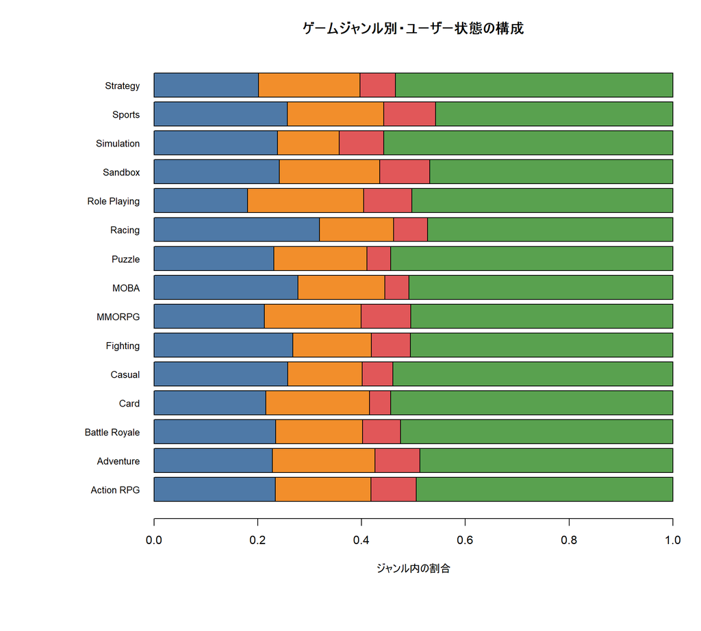

```r
genre_state <- table(d$GameGenre, d$state, useNA = "no")
genre_prop <- prop.table(genre_state, margin = 1)

par(mar = c(8, 11, 4, 2), xpd = NA)

barplot(
  t(genre_prop),
  names.arg = colnames(t(genre_prop)),
  horiz = TRUE,
  las = 1,
  axes = FALSE,
  xlim = c(0, 1),
  cex.names = 0.8,
  col = c("#4E79A7", "#F28E2B", "#E15759", "#59A14F"),
  xlab = "ジャンル内の割合",
  main = "ゲームジャンル別・ユーザー状態の構成"
)

axis(1, at = seq(0, 1, 0.2), labels = sprintf("%.1f", seq(0, 1, 0.2)))

legend(
  "bottom",
  inset = c(0, -0.48),
  xpd = NA,
  ncol = 2,
  bty = "n",
  fill = c("#4E79A7", "#F28E2B", "#E15759", "#59A14F"),
  legend = levels(d$state),
  cex = 0.8
)
```

**コード**

```r
par(xpd = FALSE)
```

二値指標を用いてジャンル別割合を記述すると、ジャンルごとに割合の違いが見られた。ただし、年齢・国・端末を調整したロジスティック回帰では、ジャンル全体の尤度比検定は有意ではなかった（p = .534）。そのため、棒グラフ上の差だけから、ジャンルによる明確な違いがあるとは結論できない。 続いて、利用者を4状態に分類し、ジャンルごとの構成を比較した。シミュレーションによるカイ二乗検定の結果、ジャンルと4状態の間に統計的に有意な関連は確認されなかった（χ² = 42.478、p = .4556）。以上から、今回の分析では、ジャンルによるユーザー状態の明確な違いは確認できなかった。

各ゲームジャンルの利用者を、低プレイのみ、低課金のみ、低プレイ・低課金の両方、どちらも低くない、の4状態に分類し、ジャンルごとの割合を比較した。 「低プレイ・低課金の両方」の割合は、Sportsで最も高く10.0%、次いでSandboxが9.7%、MMORPGが9.6%であった。一方、Cardでは4.1%、MOBAとPuzzleでは4.6%であった。ただし、ジャンルとユーザー状態の関連を検定した結果、統計的に有意な関連は確認されなかった（χ² = 42.478、p = 0.4556）。 したがって、ジャンルによって状態の割合に差があるように見えるものの、今回の分析から、ゲームジャンルとユーザー状態に明確な関連があるとはいえない。

ジャンルと4状態の検定は、期待度数が小さいカテゴリの影響を考慮し、モンテカルロ法でp値を求めた。

**コード**

```r
set.seed(20261013)
chisq.test(genre_state, simulate.p.value = TRUE, B = 10000)
```

```
    Pearson's Chi-squared test with simulated p-value (based on 10000
    replicates)

data:  genre_state
X-squared = 42.478, df = NA, p-value = 0.4556
```

シミュレーションによるカイ二乗検定の結果、ジャンルとユーザー状態の間に統計的に有意な関連は確認されなかった（χ² = 42.478、p = .4556）。したがって、今回の分析では、ゲームジャンルによるユーザー状態の明確な違いは確認できなかった。

## 4.3 4状態別の年齢分布

**コード**

```r
age_data <- d[!is.na(d$Age), ]
aggregate(Age ~ state, data = age_data, FUN = median)
```

| state | Age |
| --- | --- |
| 低プレイのみ | 32 |
| 低課金のみ | 34 |
| 低プレイ・低課金の両方 | 34 |
| どちらも低くない | 33 |

**コード**

```r
kruskal.test(Age ~ state, data = age_data)
```

```
    Kruskal-Wallis rank sum test

data:  Age by state
Kruskal-Wallis chi-squared = 1.9374, df = 3, p-value = 0.5855
```

年齢が得られた利用者を対象に、4状態間で年齢分布を比較した。各状態の年齢中央値は、「低プレイのみ」が32歳、「低課金のみ」が34歳、「低プレイ・低課金の両方」が34歳、「どちらも低くない」が33歳であった。 Kruskal–Wallis検定の結果、4状態間に統計的に有意な差は確認されなかった（χ²(3) = 1.9374、p = .5855）。したがって、今回の分析では、ユーザー状態によって年齢分布が明確に異なるとはいえない。

## 4.4 閾値の感度分析

低プレイ・低課金の判定基準を下位20%、25%、30%に変えて、両方に該当する利用者の人数と割合を比較した。

**コード**

```r
sensitivity <- do.call(rbind, lapply(c(.20, .25, .30), function(p) {
  cs <- unname(quantile(d$SessionCount, p, type = 7))
  ca <- unname(quantile(d$InAppPurchaseAmount, p, type = 7))
  both <- d$SessionCount <= cs & d$InAppPurchaseAmount <= ca
  data.frame(
    分位点_percent = 100 * p,
    プレイ境界 = cs,
    課金境界 = ca,
    両方低い人数 = sum(both),
    両方低い割合_percent = 100 * mean(both)
  )
}))
sensitivity
```

| 分位点_percent | プレイ境界 | 課金境界 | 両方低い人数 | 両方低い割合_percent |
| --- | --- | --- | --- | --- |
| 20 | 7 | 4.7400 | 112 | 3.878116 |
| 25 | 8 | 5.9875 | 217 | 7.513850 |
| 30 | 8 | 7.2000 | 276 | 9.556787 |

判定基準を下位20%から30%へ広げると、低プレイ・低課金の両方に該当する利用者は112人（3.88%）から276人（9.56%）へ増加した。このことから、該当者数と割合は判定基準の設定によって変化する。 したがって、下位25%を用いた場合の7.51%は、その基準に基づく結果として解釈する必要がある。

//「このデータには低プレイ・低課金の人が必ず7.51%いる」と決まっているわけではありません。**「プレイ回数と課金額の下位25%を低いと定義した場合、両方に該当する人は7.51%だった」**という意味です。論文では、どの基準を使った割合なのかを明記すれば、結果を正確に伝えられます。

## 4.5 考察

本研究では、利用者を「低プレイのみ」「低課金のみ」「両方」「どちらも低くない」の4状態に分類した。「低プレイのみ」は693人（24.00%）、「低課金のみ」は505人（17.49%）、「両方」は217人（7.51%）であり、プレイ回数の少なさと課金額の少なさは一部重なるものの、同じ利用者層とは限らないことが示された。

ロジスティック回帰分析では、年齢・国・端末・ジャンルとの明確な関連は確認されなかった。4状態についても、ジャンルとの関連（χ² = 42.478、p = .4556）や年齢分布の差（χ²(3) = 1.9374、p = .5855）は確認されなかった。ただし、これは関連が存在しないことの証明ではない。

感度分析では、両方に該当する割合は判定基準によって3.88～9.56%に変化した。また、本データには実際の離脱やサービス終了の記録がないため、低プレイ・低課金状態をサービス終了リスクとして解釈することはできない。今後は、観測期間が明確な利用ログや離脱記録を用いて、利用者の行動状態と継続・離脱との関係を検討する必要がある。